# Practical Machine Learning Coursera - Final Project

Jussan Da Silva Bahia Nascimento

2023-02-17

## 1.Background

This the final project of the Practical machine learning course from Johns Hopkins University on Coursera.

## 2.Goal

In this project, I will have to use the data from accelerometers on the belt, forearm, arm, and dumbell of 6 participants. They were asked to perform barbell lifts correctly and incorrectly in 5 different ways. More information is available from the website here: http://web.archive.org/web/20161224072740/http:/groupware.les.inf.puc-rio.br/har (see the section on the Weight Lifting Exercise Dataset).

The goal of this project is to predict the manner in which they did the exercise. This is the “classe” variable in the training set. Moreover we have to describe how the model was built, how cross validation is used, what is the expected out of sample error, and why the choices were made.

## 3.Data preparation

Loading packages for the analysis

```r
#Loading packages
library(caret)
library(ggplot2)
library(ggcorrplot)
library(parallel)
library(doParallel)
```

Loading dataset

```r
#Loading data
trainingTemp <- read.csv("pml-training.csv")
validation <- read.csv("pml-testing.csv")
```

## 4.Exploratory analysis

```r
#datasets' dimension
dim(trainingTemp)
```

```
## [1] 19622   160
```

```r
dim(validation)
```

```
## [1]  20 160
```

```r
#Overview of the first rows
head(trainingTemp)
```

```
##   X user_name raw_timestamp_part_1 raw_timestamp_part_2   cvtd_timestamp
## 1 1  carlitos           1323084231               788290 05/12/2011 11:23
## 2 2  carlitos           1323084231               808298 05/12/2011 11:23
## 3 3  carlitos           1323084231               820366 05/12/2011 11:23
## 4 4  carlitos           1323084232               120339 05/12/2011 11:23
## 5 5  carlitos           1323084232               196328 05/12/2011 11:23
## 6 6  carlitos           1323084232               304277 05/12/2011 11:23
##   new_window num_window roll_belt pitch_belt yaw_belt total_accel_belt
## 1         no         11      1.41       8.07    -94.4                3
## 2         no         11      1.41       8.07    -94.4                3
## 3         no         11      1.42       8.07    -94.4                3
## 4         no         12      1.48       8.05    -94.4                3
## 5         no         12      1.48       8.07    -94.4                3
## 6         no         12      1.45       8.06    -94.4                3
##   kurtosis_roll_belt kurtosis_picth_belt kurtosis_yaw_belt skewness_roll_belt
```

[output cut: 251 more lines]

```r
head(validation)
```

```
##   X user_name raw_timestamp_part_1 raw_timestamp_part_2   cvtd_timestamp
## 1 1     pedro           1323095002               868349 05/12/2011 14:23
## 2 2    jeremy           1322673067               778725 30/11/2011 17:11
## 3 3    jeremy           1322673075               342967 30/11/2011 17:11
## 4 4    adelmo           1322832789               560311 02/12/2011 13:33
## 5 5    eurico           1322489635               814776 28/11/2011 14:13
## 6 6    jeremy           1322673149               510661 30/11/2011 17:12
##   new_window num_window roll_belt pitch_belt yaw_belt total_accel_belt
## 1         no         74    123.00      27.00    -4.75               20
## 2         no        431      1.02       4.87   -88.90                4
## 3         no        439      0.87       1.82   -88.50                5
## 4         no        194    125.00     -41.60   162.00               17
## 5         no        235      1.35       3.33   -88.60                3
## 6         no        504     -5.92       1.59   -87.70                4
##   kurtosis_roll_belt kurtosis_picth_belt kurtosis_yaw_belt skewness_roll_belt
```

[output cut: 251 more lines]

#### 4.1 Creating training and testing set randomly

Training and Testing set are created randomly considering sizes of 70% and 30% respectively. These datasetes will be used for the Cross-validation later.

```r
set.seed(123)
inTrain <- createDataPartition(y=trainingTemp$classe,
                               p=0.7, list=FALSE)

training <- trainingTemp[inTrain,]
testing <- trainingTemp[-inTrain,]

#datasets' dimension
dim(training)
```

```
## [1] 13737   160
```

```r
dim(testing)
```

```
## [1] 5885  160
```

```r
#Checking proportions of each classe and its level.
prop.table(table(training$classe))
```

```
##
##         A         B         C         D         E
## 0.2843416 0.1934920 0.1744195 0.1639368 0.1838101
```

#### 4.2 Checking NAs and Null rows

It’s important to treat the NAs and/or Null values as the datasets need to be completed in order to train the machine learning models.

```r
#checking NAs
colSums(is.na(training))
```

```
##                        X                user_name     raw_timestamp_part_1
##                        0                        0                        0
##     raw_timestamp_part_2           cvtd_timestamp               new_window
##                        0                        0                        0
##               num_window                roll_belt               pitch_belt
##                        0                        0                        0
##                 yaw_belt         total_accel_belt       kurtosis_roll_belt
##                        0                        0                        0
##      kurtosis_picth_belt        kurtosis_yaw_belt       skewness_roll_belt
##                        0                        0                        0
##     skewness_roll_belt.1        skewness_yaw_belt            max_roll_belt
##                        0                        0                    13463
##           max_picth_belt             max_yaw_belt            min_roll_belt
##                    13463                        0                    13463
##           min_pitch_belt             min_yaw_belt      amplitude_roll_belt
##                    13463                        0                    13463
##     amplitude_pitch_belt       amplitude_yaw_belt     var_total_accel_belt
##                    13463                        0                    13463
##            avg_roll_belt         stddev_roll_belt            var_roll_belt
##                    13463                    13463                    13463
##           avg_pitch_belt        stddev_pitch_belt           var_pitch_belt
##                    13463                    13463                    13463
##             avg_yaw_belt          stddev_yaw_belt             var_yaw_belt
##                    13463                    13463                    13463
##             gyros_belt_x             gyros_belt_y             gyros_belt_z
##                        0                        0                        0
##             accel_belt_x             accel_belt_y             accel_belt_z
##                        0                        0                        0
##            magnet_belt_x            magnet_belt_y            magnet_belt_z
##                        0                        0                        0
##                 roll_arm                pitch_arm                  yaw_arm
##                        0                        0                        0
##          total_accel_arm            var_accel_arm             avg_roll_arm
##                        0                    13463                    13463
##          stddev_roll_arm             var_roll_arm            avg_pitch_arm
##                    13463                    13463                    13463
##         stddev_pitch_arm            var_pitch_arm              avg_yaw_arm
##                    13463                    13463                    13463
##           stddev_yaw_arm              var_yaw_arm              gyros_arm_x
##                    13463                    13463                        0
```

[output cut: 53 more lines]

```
##                        0                        0                    13463
##         avg_roll_forearm      stddev_roll_forearm         var_roll_forearm
##                    13463                    13463                    13463
##        avg_pitch_forearm     stddev_pitch_forearm        var_pitch_forearm
##                    13463                    13463                    13463
##          avg_yaw_forearm       stddev_yaw_forearm          var_yaw_forearm
##                    13463                    13463                    13463
##          gyros_forearm_x          gyros_forearm_y          gyros_forearm_z
##                        0                        0                        0
##          accel_forearm_x          accel_forearm_y          accel_forearm_z
##                        0                        0                        0
##         magnet_forearm_x         magnet_forearm_y         magnet_forearm_z
##                        0                        0                        0
##                   classe
##                        0
```

We can observe that some colunms has thousands of NAs which represents aound 98% of the total rows. This columns will be removed as it has very few information for model training and predictions.

```r
#98% of rows with NAs will be removed form the training dataset
training <- training[ , colSums(is.na(training))<13451]

#double checking if columns were removed
colSums(is.na(training))
```

```
##                       X               user_name    raw_timestamp_part_1
##                       0                       0                       0
##    raw_timestamp_part_2          cvtd_timestamp              new_window
##                       0                       0                       0
##              num_window               roll_belt              pitch_belt
##                       0                       0                       0
##                yaw_belt        total_accel_belt      kurtosis_roll_belt
##                       0                       0                       0
##     kurtosis_picth_belt       kurtosis_yaw_belt      skewness_roll_belt
##                       0                       0                       0
##    skewness_roll_belt.1       skewness_yaw_belt            max_yaw_belt
##                       0                       0                       0
##            min_yaw_belt      amplitude_yaw_belt            gyros_belt_x
##                       0                       0                       0
##            gyros_belt_y            gyros_belt_z            accel_belt_x
##                       0                       0                       0
##            accel_belt_y            accel_belt_z           magnet_belt_x
##                       0                       0                       0
##           magnet_belt_y           magnet_belt_z                roll_arm
##                       0                       0                       0
##               pitch_arm                 yaw_arm         total_accel_arm
##                       0                       0                       0
##             gyros_arm_x             gyros_arm_y             gyros_arm_z
##                       0                       0                       0
##             accel_arm_x             accel_arm_y             accel_arm_z
##                       0                       0                       0
##            magnet_arm_x            magnet_arm_y            magnet_arm_z
##                       0                       0                       0
##       kurtosis_roll_arm      kurtosis_picth_arm        kurtosis_yaw_arm
##                       0                       0                       0
##       skewness_roll_arm      skewness_pitch_arm        skewness_yaw_arm
##                       0                       0                       0
##           roll_dumbbell          pitch_dumbbell            yaw_dumbbell
##                       0                       0                       0
##  kurtosis_roll_dumbbell kurtosis_picth_dumbbell   kurtosis_yaw_dumbbell
##                       0                       0                       0
##  skewness_roll_dumbbell skewness_pitch_dumbbell   skewness_yaw_dumbbell
##                       0                       0                       0
##        max_yaw_dumbbell        min_yaw_dumbbell  amplitude_yaw_dumbbell
##                       0                       0                       0
##    total_accel_dumbbell        gyros_dumbbell_x        gyros_dumbbell_y
##                       0                       0                       0
##        gyros_dumbbell_z        accel_dumbbell_x        accel_dumbbell_y
##                       0                       0                       0
##        accel_dumbbell_z       magnet_dumbbell_x       magnet_dumbbell_y
##                       0                       0                       0
##       magnet_dumbbell_z            roll_forearm           pitch_forearm
##                       0                       0                       0
##             yaw_forearm   kurtosis_roll_forearm  kurtosis_picth_forearm
##                       0                       0                       0
##    kurtosis_yaw_forearm   skewness_roll_forearm  skewness_pitch_forearm
##                       0                       0                       0
##    skewness_yaw_forearm         max_yaw_forearm         min_yaw_forearm
##                       0                       0                       0
##   amplitude_yaw_forearm     total_accel_forearm         gyros_forearm_x
##                       0                       0                       0
##         gyros_forearm_y         gyros_forearm_z         accel_forearm_x
##                       0                       0                       0
##         accel_forearm_y         accel_forearm_z        magnet_forearm_x
##                       0                       0                       0
##        magnet_forearm_y        magnet_forearm_z                  classe
##                       0                       0                       0
```

```r
#checking Null values
colSums(training=="")
```

```
##                       X               user_name    raw_timestamp_part_1
##                       0                       0                       0
##    raw_timestamp_part_2          cvtd_timestamp              new_window
##                       0                       0                       0
##              num_window               roll_belt              pitch_belt
##                       0                       0                       0
##                yaw_belt        total_accel_belt      kurtosis_roll_belt
##                       0                       0                   13463
##     kurtosis_picth_belt       kurtosis_yaw_belt      skewness_roll_belt
##                   13463                   13463                   13463
##    skewness_roll_belt.1       skewness_yaw_belt            max_yaw_belt
##                   13463                   13463                   13463
##            min_yaw_belt      amplitude_yaw_belt            gyros_belt_x
##                   13463                   13463                       0
##            gyros_belt_y            gyros_belt_z            accel_belt_x
##                       0                       0                       0
##            accel_belt_y            accel_belt_z           magnet_belt_x
##                       0                       0                       0
##           magnet_belt_y           magnet_belt_z                roll_arm
##                       0                       0                       0
##               pitch_arm                 yaw_arm         total_accel_arm
##                       0                       0                       0
##             gyros_arm_x             gyros_arm_y             gyros_arm_z
##                       0                       0                       0
##             accel_arm_x             accel_arm_y             accel_arm_z
##                       0                       0                       0
##            magnet_arm_x            magnet_arm_y            magnet_arm_z
##                       0                       0                       0
##       kurtosis_roll_arm      kurtosis_picth_arm        kurtosis_yaw_arm
##                   13463                   13463                   13463
##       skewness_roll_arm      skewness_pitch_arm        skewness_yaw_arm
##                   13463                   13463                   13463
##           roll_dumbbell          pitch_dumbbell            yaw_dumbbell
##                       0                       0                       0
##  kurtosis_roll_dumbbell kurtosis_picth_dumbbell   kurtosis_yaw_dumbbell
##                   13463                   13463                   13463
##  skewness_roll_dumbbell skewness_pitch_dumbbell   skewness_yaw_dumbbell
##                   13463                   13463                   13463
##        max_yaw_dumbbell        min_yaw_dumbbell  amplitude_yaw_dumbbell
##                   13463                   13463                   13463
##    total_accel_dumbbell        gyros_dumbbell_x        gyros_dumbbell_y
##                       0                       0                       0
##        gyros_dumbbell_z        accel_dumbbell_x        accel_dumbbell_y
##                       0                       0                       0
##        accel_dumbbell_z       magnet_dumbbell_x       magnet_dumbbell_y
##                       0                       0                       0
##       magnet_dumbbell_z            roll_forearm           pitch_forearm
##                       0                       0                       0
##             yaw_forearm   kurtosis_roll_forearm  kurtosis_picth_forearm
##                       0                   13463                   13463
##    kurtosis_yaw_forearm   skewness_roll_forearm  skewness_pitch_forearm
##                   13463                   13463                   13463
##    skewness_yaw_forearm         max_yaw_forearm         min_yaw_forearm
##                   13463                   13463                   13463
##   amplitude_yaw_forearm     total_accel_forearm         gyros_forearm_x
##                   13463                       0                       0
##         gyros_forearm_y         gyros_forearm_z         accel_forearm_x
##                       0                       0                       0
##         accel_forearm_y         accel_forearm_z        magnet_forearm_x
##                       0                       0                       0
##        magnet_forearm_y        magnet_forearm_z                  classe
##                       0                       0                       0
```

The same situation is observed for the Null values. Some columns have thousands of Null values with represents aound 98% of the total rows. This columns will also be removed as it has very few information for model training and predictions.

```r
##98% of rows with NAs will be removed form the training dataset
training <- training[ , colSums(training=="")<13451]

#double checking empty rows
colSums(training=="")
```

```
##                    X            user_name raw_timestamp_part_1
##                    0                    0                    0
## raw_timestamp_part_2       cvtd_timestamp           new_window
##                    0                    0                    0
##           num_window            roll_belt           pitch_belt
##                    0                    0                    0
##             yaw_belt     total_accel_belt         gyros_belt_x
##                    0                    0                    0
##         gyros_belt_y         gyros_belt_z         accel_belt_x
##                    0                    0                    0
##         accel_belt_y         accel_belt_z        magnet_belt_x
##                    0                    0                    0
##        magnet_belt_y        magnet_belt_z             roll_arm
##                    0                    0                    0
##            pitch_arm              yaw_arm      total_accel_arm
##                    0                    0                    0
##          gyros_arm_x          gyros_arm_y          gyros_arm_z
##                    0                    0                    0
##          accel_arm_x          accel_arm_y          accel_arm_z
##                    0                    0                    0
##         magnet_arm_x         magnet_arm_y         magnet_arm_z
##                    0                    0                    0
##        roll_dumbbell       pitch_dumbbell         yaw_dumbbell
##                    0                    0                    0
## total_accel_dumbbell     gyros_dumbbell_x     gyros_dumbbell_y
##                    0                    0                    0
##     gyros_dumbbell_z     accel_dumbbell_x     accel_dumbbell_y
##                    0                    0                    0
##     accel_dumbbell_z    magnet_dumbbell_x    magnet_dumbbell_y
##                    0                    0                    0
##    magnet_dumbbell_z         roll_forearm        pitch_forearm
##                    0                    0                    0
##          yaw_forearm  total_accel_forearm      gyros_forearm_x
##                    0                    0                    0
##      gyros_forearm_y      gyros_forearm_z      accel_forearm_x
##                    0                    0                    0
##      accel_forearm_y      accel_forearm_z     magnet_forearm_x
##                    0                    0                    0
##     magnet_forearm_y     magnet_forearm_z               classe
##                    0                    0                    0
```

#### 4.3 Checking Dataset structure

In this session I checked the structure of the data and the classes of each variable making sure they are in the correct format for the modelling part.

```r
str(training)
```

```
## 'data.frame':    13737 obs. of  60 variables:
##  $ X                   : int  1 2 5 7 9 10 12 13 14 16 ...
##  $ user_name           : chr  "carlitos" "carlitos" "carlitos" "carlitos" ...
##  $ raw_timestamp_part_1: int  1323084231 1323084231 1323084232 1323084232 1323084232 1323084232 1323084232 1323084232 1323084232 1323084232 ...
##  $ raw_timestamp_part_2: int  788290 808298 196328 368296 484323 484434 528316 560359 576390 644302 ...
##  $ cvtd_timestamp      : chr  "05/12/2011 11:23" "05/12/2011 11:23" "05/12/2011 11:23" "05/12/2011 11:23" ...
##  $ new_window          : chr  "no" "no" "no" "no" ...
##  $ num_window          : int  11 11 12 12 12 12 12 12 12 12 ...
##  $ roll_belt           : num  1.41 1.41 1.48 1.42 1.43 1.45 1.43 1.42 1.42 1.48 ...
##  $ pitch_belt          : num  8.07 8.07 8.07 8.09 8.16 8.17 8.18 8.2 8.21 8.15 ...
##  $ yaw_belt            : num  -94.4 -94.4 -94.4 -94.4 -94.4 -94.4 -94.4 -94.4 -94.4 -94.4 ...
##  $ total_accel_belt    : int  3 3 3 3 3 3 3 3 3 3 ...
##  $ gyros_belt_x        : num  0 0.02 0.02 0.02 0.02 0.03 0.02 0.02 0.02 0 ...
##  $ gyros_belt_y        : num  0 0 0.02 0 0 0 0 0 0 0 ...
##  $ gyros_belt_z        : num  -0.02 -0.02 -0.02 -0.02 -0.02 0 -0.02 0 -0.02 0 ...
```

[output cut: 46 more lines]

```r
training <- subset(training,select=-c(X))

training$classe <- as.factor(training$classe)
training$user_name <- as.factor(training$user_name)
training$new_window <- as.factor(training$new_window)
training$cvtd_timestamp <- strptime(training$cvtd_timestamp, format = "%d/%m/%Y %H:%M")
training$cvtd_timestamp <- as.POSIXct(training$cvtd_timestamp)
training$cvtd_timestamp <- as.numeric(training$cvtd_timestamp)
```

Variable X is excluded as it looks like a row number and it’s not mentioned at all in the website of the research. Moreover character variables are converting to factor or numeric variable depending on its nature.

## 5.Feature selection

Feature selection is an important steps as:

– Provides better Accuracy: removing irrelevant features let the models make decisions only using important features.

– Avoid Overfitting: the models will not put weights in irrelevant features.

– Improve running time: decreasing the dimension of the data makes the models run faster.

So I started the feature selection process by identifying and removing highly correlated independent variables, as they are redundant. Although multicollinearity doesn’t affect the model’s performance, it will affect the interpretability. If we don’t remove the multicollinearity, we will never know how much a variable contributes to the result.

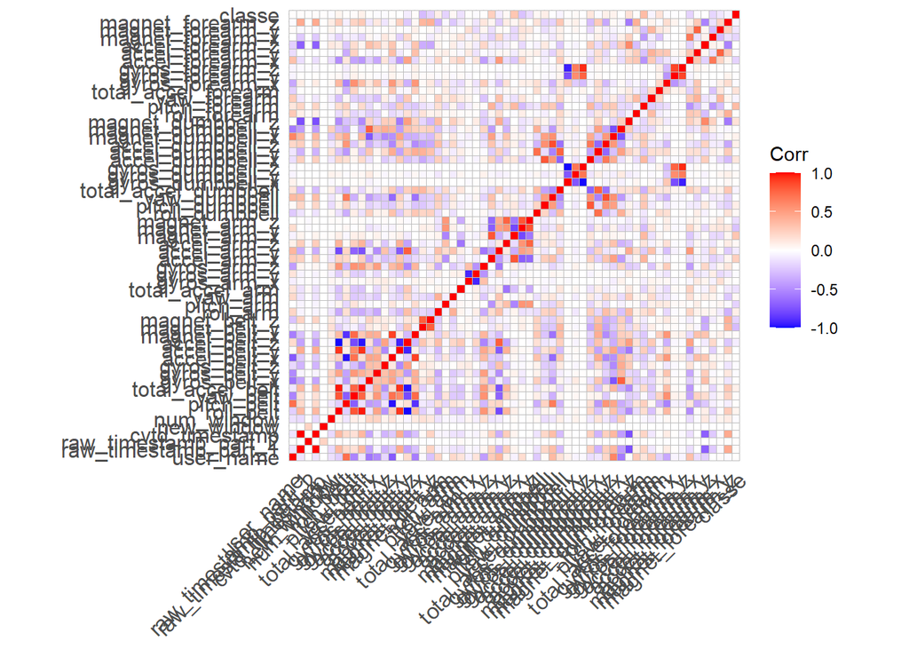

```r
#copying training set
training_aux <- training

#converting factor variables to numeric to use in correlation analysis
training_aux$classe <- as.numeric(training_aux$classe)
training_aux$new_window <- as.numeric(training_aux$new_window)
training_aux$user_name <- as.numeric(training_aux$user_name)

#checking correlation matrix
cor_matrix <- data.frame(cor(training_aux))
ggcorrplot(cor_matrix)
```

We can observe from the correlation Matrix that some independent variables are correlated to each other. I use the findCorrelation from Caret package. If two variables have a higher correlation than the cutoff, the function removes the variable with the largest mean absolute correlation.

```r
fCorr <- findCorrelation(cor(subset(training_aux,select=-c(classe))), cutoff=0.75)
names(training_aux[,fCorr])
```

```
##  [1] "accel_belt_z"         "roll_belt"            "accel_arm_y"
##  [4] "accel_belt_y"         "total_accel_belt"     "accel_belt_x"
##  [7] "accel_dumbbell_z"     "pitch_belt"           "magnet_dumbbell_x"
## [10] "magnet_dumbbell_y"    "accel_dumbbell_y"     "cvtd_timestamp"
## [13] "raw_timestamp_part_1" "accel_arm_x"          "accel_dumbbell_x"
## [16] "accel_arm_z"          "magnet_arm_y"         "magnet_belt_z"
## [19] "accel_forearm_y"      "gyros_dumbbell_x"     "gyros_forearm_y"
## [22] "gyros_dumbbell_z"     "gyros_arm_x"
```

```r
training <- training[ ,!names(training) %in% names(training_aux[,fCorr])]
```

I can then check the variable importance of the remaining variables using the filterVarImp function from the Caret package as well. For classification, this function uses ROC curve analysis on each predictor and use area under the curve as scores.

```r
#use roc_curve area as score
roc_imp <- filterVarImp(x = training[,1:35], y = training$classe)

#sort the score in decreasing order
roc_imp <- data.frame(cbind(variable = rownames(roc_imp), score = roc_imp[,1]))
roc_imp$score <- as.double(roc_imp$score)
roc_imp[order(roc_imp$score,decreasing = TRUE),]
```

```
##                variable     score
## 26        pitch_forearm 0.6993185
## 24    magnet_dumbbell_z 0.6784500
## 4            num_window 0.6686721
## 17         magnet_arm_x 0.6682860
## 18         magnet_arm_z 0.6611476
## 20       pitch_dumbbell 0.6587616
## 19        roll_dumbbell 0.6288501
## 31      accel_forearm_x 0.6263428
## 33     magnet_forearm_x 0.6247014
## 11             roll_arm 0.6107920
## 14      total_accel_arm 0.6055595
## 25         roll_forearm 0.5975489
## 12            pitch_arm 0.5824010
## 9         magnet_belt_x 0.5783595
```

[output cut: 21 more lines]

```r
#filtering Validation and Testing datasets with the same columns in the Training dataset
validation <- validation[ ,names(validation) %in% names(training)]
testing <- testing[ ,names(testing) %in% names(training)]

#getting classes
trainingClass <- sapply(subset(training,select=-c(classe)), class)
testingClass <- sapply(subset(testing,select=-c(classe)), class)
validationClass <- sapply(validation, class)

#comparing classes from the different variables between the two datasets
colClassCheck <- data.frame(trainingCol = trainingClass,
                            testingCol = testingClass,
                            validationCol = validationClass,
                            TrainingVsTesting =  (trainingClass == testingClass),
                            TrainingVsValidation =  (trainingClass == validationClass))
colClassCheck
```

```
##                      trainingCol testingCol validationCol TrainingVsTesting
## user_name                 factor  character     character             FALSE
## raw_timestamp_part_2     integer    integer       integer              TRUE
## new_window                factor  character     character             FALSE
## num_window               integer    integer       integer              TRUE
## yaw_belt                 numeric    numeric       numeric              TRUE
## gyros_belt_x             numeric    numeric       numeric              TRUE
## gyros_belt_y             numeric    numeric       numeric              TRUE
## gyros_belt_z             numeric    numeric       numeric              TRUE
## magnet_belt_x            integer    integer       integer              TRUE
## magnet_belt_y            integer    integer       integer              TRUE
## roll_arm                 numeric    numeric       numeric              TRUE
## pitch_arm                numeric    numeric       numeric              TRUE
## yaw_arm                  numeric    numeric       numeric              TRUE
## total_accel_arm          integer    integer       integer              TRUE
## gyros_arm_y              numeric    numeric       numeric              TRUE
## gyros_arm_z              numeric    numeric       numeric              TRUE
## magnet_arm_x             integer    integer       integer              TRUE
## magnet_arm_z             integer    integer       integer              TRUE
## roll_dumbbell            numeric    numeric       numeric              TRUE
## pitch_dumbbell           numeric    numeric       numeric              TRUE
## yaw_dumbbell             numeric    numeric       numeric              TRUE
## total_accel_dumbbell     integer    integer       integer              TRUE
## gyros_dumbbell_y         numeric    numeric       numeric              TRUE
## magnet_dumbbell_z        numeric    numeric       integer              TRUE
## roll_forearm             numeric    numeric       numeric              TRUE
## pitch_forearm            numeric    numeric       numeric              TRUE
## yaw_forearm              numeric    numeric       numeric              TRUE
## total_accel_forearm      integer    integer       integer              TRUE
## gyros_forearm_x          numeric    numeric       numeric              TRUE
## gyros_forearm_z          numeric    numeric       numeric              TRUE
## accel_forearm_x          integer    integer       integer              TRUE
## accel_forearm_z          integer    integer       integer              TRUE
## magnet_forearm_x         integer    integer       integer              TRUE
## magnet_forearm_y         numeric    numeric       integer              TRUE
## magnet_forearm_z         numeric    numeric       integer              TRUE
##                      TrainingVsValidation
## user_name                           FALSE
## raw_timestamp_part_2                 TRUE
## new_window                          FALSE
```

[output cut: 17 more lines]

```
## yaw_dumbbell                         TRUE
## total_accel_dumbbell                 TRUE
## gyros_dumbbell_y                     TRUE
## magnet_dumbbell_z                   FALSE
## roll_forearm                         TRUE
## pitch_forearm                        TRUE
## yaw_forearm                          TRUE
## total_accel_forearm                  TRUE
## gyros_forearm_x                      TRUE
## gyros_forearm_z                      TRUE
## accel_forearm_x                      TRUE
## accel_forearm_z                      TRUE
## magnet_forearm_x                     TRUE
## magnet_forearm_y                    FALSE
## magnet_forearm_z                    FALSE
```

```r
#converting variables
testing$classe <- as.factor(testing$classe)
testing$user_name <- as.factor(testing$user_name)
testing$new_window <- as.factor(testing$new_window)

validation$user_name <- as.factor(validation$user_name)
validation$new_window <- as.factor(validation$new_window)
validation$magnet_dumbbell_z <- as.numeric(validation$magnet_dumbbell_z)
validation$magnet_forearm_y <- as.numeric(validation$magnet_forearm_y)
validation$magnet_forearm_z <- as.numeric(validation$magnet_forearm_z)
```

## 6.Evaluating Machine Learning Algorithms.

#### 6.1 Cross-validation

In this section I use the two of the most used machine learning algorithms, Random forest and Boosting. Using these algorithms, I perform Cross-validation using 10 K-folds and compute the average accuracy of each one of the models. I use the parallel processing to run the models faster.

```r
#parallel processing setup
cluster <- makeCluster(detectCores() - 1) # convention to leave 1 core for OS
registerDoParallel(cluster)

#cross-validation setup
fitControl <- trainControl(method = "cv",
                           number = 10,
                           allowParallel = TRUE)


#training the models
fit.rf <- train(classe ~ ., method="rf",data=training,trControl=fitControl)
fit.gbm <- train(classe ~., method="gbm",data=training, verbose=FALSE,trControl=fitControl)

#stopping parallel processing
stopCluster(cluster)
registerDoSEQ()

#checking model's average accuracy
confusionMatrix.train(fit.rf)
```

```
## Cross-Validated (10 fold) Confusion Matrix
##
## (entries are percentual average cell counts across resamples)
##
##           Reference
## Prediction    A    B    C    D    E
##          A 28.4  0.1  0.0  0.0  0.0
##          B  0.0 19.2  0.1  0.0  0.0
##          C  0.0  0.0 17.4  0.0  0.0
##          D  0.0  0.0  0.0 16.3  0.0
##          E  0.0  0.0  0.0  0.0 18.4
##
##  Accuracy (average) : 0.9972
```

```r
confusionMatrix.train(fit.gbm)
```

```
## Cross-Validated (10 fold) Confusion Matrix
##
## (entries are percentual average cell counts across resamples)
##
##           Reference
## Prediction    A    B    C    D    E
##          A 28.4  0.1  0.0  0.0  0.0
##          B  0.1 19.1  0.1  0.1  0.0
##          C  0.0  0.1 17.2  0.2  0.0
##          D  0.0  0.0  0.1 16.1  0.2
##          E  0.0  0.0  0.0  0.0 18.2
##
##  Accuracy (average) : 0.9902
```

As we can see, random forest gives us the best accuracy.

#### 6.2 Validation

Finally I check the accuracy of each model on the testing set. This will give us an independent final check on the accuracy of the best model. I run the models on the testing set and summarize the results in a confusion matrix.

```r
pred.rf <- predict(fit.rf, newdata = testing)
confusionMatrix(pred.rf, testing$classe)
```

```
## Confusion Matrix and Statistics
##
##           Reference
## Prediction    A    B    C    D    E
##          A 1673    1    0    0    0
##          B    1 1137    2    1    1
##          C    0    1 1024    2    0
##          D    0    0    0  961    1
##          E    0    0    0    0 1080
##
## Overall Statistics
##
##                Accuracy : 0.9983
##                  95% CI : (0.9969, 0.9992)
##     No Information Rate : 0.2845
##     P-Value [Acc > NIR] : < 2.2e-16
##
##                   Kappa : 0.9979
##
##  Mcnemar's Test P-Value : NA
##
## Statistics by Class:
##
##                      Class: A Class: B Class: C Class: D Class: E
## Sensitivity            0.9994   0.9982   0.9981   0.9969   0.9982
## Specificity            0.9998   0.9989   0.9994   0.9998   1.0000
## Pos Pred Value         0.9994   0.9956   0.9971   0.9990   1.0000
## Neg Pred Value         0.9998   0.9996   0.9996   0.9994   0.9996
## Prevalence             0.2845   0.1935   0.1743   0.1638   0.1839
## Detection Rate         0.2843   0.1932   0.1740   0.1633   0.1835
## Detection Prevalence   0.2845   0.1941   0.1745   0.1635   0.1835
## Balanced Accuracy      0.9996   0.9986   0.9987   0.9983   0.9991
```

```r
pred.gbm <- predict(fit.gbm, newdata = testing)
confusionMatrix(pred.gbm, testing$classe)
```

```
## Confusion Matrix and Statistics
##
##           Reference
## Prediction    A    B    C    D    E
##          A 1671    7    0    0    3
##          B    3 1126   11    6    0
##          C    0    6 1013   11    3
##          D    0    0    2  947    5
##          E    0    0    0    0 1071
##
## Overall Statistics
##
##                Accuracy : 0.9903
##                  95% CI : (0.9875, 0.9927)
##     No Information Rate : 0.2845
##     P-Value [Acc > NIR] : < 2.2e-16
##
##                   Kappa : 0.9877
##
##  Mcnemar's Test P-Value : NA
##
## Statistics by Class:
##
##                      Class: A Class: B Class: C Class: D Class: E
## Sensitivity            0.9982   0.9886   0.9873   0.9824   0.9898
## Specificity            0.9976   0.9958   0.9959   0.9986   1.0000
## Pos Pred Value         0.9941   0.9825   0.9806   0.9927   1.0000
## Neg Pred Value         0.9993   0.9973   0.9973   0.9966   0.9977
## Prevalence             0.2845   0.1935   0.1743   0.1638   0.1839
## Detection Rate         0.2839   0.1913   0.1721   0.1609   0.1820
## Detection Prevalence   0.2856   0.1947   0.1755   0.1621   0.1820
## Balanced Accuracy      0.9979   0.9922   0.9916   0.9905   0.9949
```

Random forest is the model selected with the highest accuracy.

## 7.Quiz

For the final QUIZ I use the Random forest model selected previously and apply it on the validation set.

```r
pred <- predict(fit.rf, newdata = validation)
pred

data.frame(case = c(1:20), pred)
```

[output not shown]